# Investigate flight performance of U.S. domestic carriers from 2005-2015

Ivy Huong Nguyen

March 30, 2017

## **INTRODUCTION**

In this project, a investigation of flight performance of all U.S. domestic carriers will be carried out. The dataset for this study contains information of all U.S. carriers regarding flight delays and performace. This dataset was obtained from the following link: https://www.transtats.bts.gov/OT_Delay/OT_DelayCause1.asp?pn=1, which includes data collected from January 2005 to January 2015. A detailed study will be focused on the top five carriers with the largest number of on-time flights and top five airlines with the largest number of delayed flights caused by different reasons.

## **DATA EXPLORATORY SECTION**

### **Data Structure**

```
## 'data.frame':    170077 obs. of  22 variables:
##  $ year               : int  2005 2005 2005 2005 2005 2005 2005 2005 2005 2005 ...
##  $  month             : int  1 1 1 1 1 1 1 1 1 1 ...
##  $ carrier            : Factor w/ 26 levels "9E","AA","AQ",..: 2 2 2 2 2 2 2 2 2 2 ...
##  $ carrier_name       : Factor w/ 27 levels "AirTran Airways Corporation",..: 4 4 4 4 4 4 4 4 4 4 ...
##  $ airport            : Factor w/ 371 levels "ABE","ABI","ABQ",..: 3 23 25 30 36 43 45 56 57 74 ...
##  $ airport_name       : Factor w/ 371 levels "Aberdeen, SD: Aberdeen Regional",..: 8 19 22 138 35 237 39 47 24 58 ...
##  $ arr_flights        : num  274 626 827 278 93 ...
##  $ arr_del15          : num  67 187 182 68 23 76 432 35 135 26 ...
##  $ carrier_ct         : num  19.57 45.95 42.98 17.38 6.49 ...
##  $  weather_ct        : num  11.36 13.17 27.87 10.51 2.57 ...
##  $ nas_ct             : num  13.03 79.13 42.75 16.39 2.56 ...
##  $ security_ct        : num  0 0 0.9 0 0 0 0 0 0 0 ...
##  $ late_aircraft_ct   : num  23.1 48.8 67.5 23.7 11.4 ...
##  $ arr_cancelled      : num  3 37 22 15 0 7 156 0 25 7 ...
##  $ arr_diverted       : num  0 0 0 0 1 0 3 0 3 0 ...
##  $  arr_delay         : num  3267 11243 9767 3258 1110 ...
##  $  carrier_delay     : num  845 2725 2365 723 282 ...
##  $ weather_delay      : num  684 764 1447 611 105 ...
##  $ nas_delay          : num  410 4530 1647 472 77 ...
##  $ security_delay     : num  0 0 27 0 0 0 0 0 0 0 ...
##  $ late_aircraft_delay: num  1328 3224 4281 1452 646 ...
##  $                    : logi  NA NA NA NA NA NA ...
```

```
##       year           month          carrier
##  Min.   :2005   Min.   : 1.000   OO     :17418
##  1st Qu.:2007   1st Qu.: 3.000   EV     :16271
##  Median :2009   Median : 6.000   MQ     :14716
##  Mean   :2009   Mean   : 6.463   DL     :13482
##  3rd Qu.:2012   3rd Qu.: 9.000   AA     : 9652
##  Max.   :2015   Max.   :12.000   YV     : 9429
##                                  (Other):89109
##                        carrier_name      airport
##  SkyWest Airlines Inc.       :17418   LAX    :  1742
##  ExpressJet Airlines Inc.    :15425   LAS    :  1733
##  Delta Air Lines Inc.        :13482   PHX    :  1705
##  American Eagle Airlines Inc.:13461   DEN    :  1682
##  Atlantic Southeast Airlines :10286   SAN    :  1678
##  American Airlines Inc.      : 9652   DTW    :  1677
##  (Other)                     :90353   (Other):159860
##                                         airport_name     arr_flights
##  Los Angeles, CA: Los Angeles International   :  1742   Min.   :    1.0
##  Las Vegas, NV: McCarran International        :  1733   1st Qu.:   62.0
##  Phoenix, AZ: Phoenix Sky Harbor International:  1705   Median :  131.0
##  Denver, CO: Denver International             :  1682   Mean   :  391.6
##  San Diego, CA: San Diego International       :  1678   3rd Qu.:  283.0
##  Detroit, MI: Detroit Metro Wayne County      :  1677   Max.   :20283.0
##  (Other)                                      :159860   NA's   :279
##    arr_del15         carrier_ct        weather_ct          nas_ct
##  Min.   :   0.00   Min.   :   0.00   Min.   :  0.000   Min.   :   0.00
##  1st Qu.:  12.00   1st Qu.:   4.03   1st Qu.:  0.000   1st Qu.:   2.26
##  Median :  27.00   Median :   9.81   Median :  0.700   Median :   6.67
##  Mean   :  79.73   Mean   :  22.50   Mean   :  2.796   Mean   :  26.55
##  3rd Qu.:  62.00   3rd Qu.:  21.86   3rd Qu.:  2.220   3rd Qu.:  17.29
##  Max.   :6377.00   Max.   :1792.07   Max.   :717.940   Max.   :3962.83
##  NA's   :317       NA's   :279       NA's   :279       NA's   :279
##   security_ct      late_aircraft_ct  arr_cancelled       arr_diverted
##  Min.   : 0.0000   Min.   :   0.00   Min.   :   0.000   Min.   :  0.0000
##  1st Qu.: 0.0000   1st Qu.:   2.00   1st Qu.:   0.000   1st Qu.:  0.0000
##  Median : 0.0000   Median :   7.00   Median :   1.000   Median :  0.0000
##  Mean   : 0.1866   Mean   :  27.68   Mean   :   6.987   Mean   :  0.8958
##  3rd Qu.: 0.0000   3rd Qu.:  19.11   3rd Qu.:   5.000   3rd Qu.:  1.0000
##  Max.   :80.5600   Max.   :1885.47   Max.   :1389.000   Max.   :256.0000
##  NA's   :279       NA's   :279       NA's   :279        NA's   :279
##     arr_delay      carrier_delay   weather_delay       nas_delay
##  Min.   :     0   Min.   :     0   Min.   :    0.0   Min.   :     0.0
##  1st Qu.:   542   1st Qu.:   190   1st Qu.:    0.0   1st Qu.:    77.0
##  Median :  1366   Median :   495   Median :   30.0   Median :   244.0
##  Mean   :  4398   Mean   :  1279   Mean   :  218.4   Mean   :  1200.5
##  3rd Qu.:  3306   3rd Qu.:  1156   3rd Qu.:  168.0   3rd Qu.:   674.8
##  Max.   :433687   Max.   :134693   Max.   :57707.0   Max.   :238440.0
##  NA's   :279      NA's   :279      NA's   :279       NA's   :279
##  security_delay     late_aircraft_delay
##  Min.   :   0.000   Min.   :     0      Mode:logical
##  1st Qu.:   0.000   1st Qu.:   104      NA's:170077
##  Median :   0.000   Median :   409
##  Mean   :   6.891   Mean   :  1694
##  3rd Qu.:   0.000   3rd Qu.:  1204
##  Max.   :3119.000   Max.   :148181
##  NA's   :279        NA's   :279
```

```
##   year  month carrier           carrier_name airport
## 1 2005      1      AA American Airlines Inc.     ABQ
## 2 2005      1      AA American Airlines Inc.     ATL
## 3 2005      1      AA American Airlines Inc.     AUS
## 4 2005      1      AA American Airlines Inc.     BDL
## 5 2005      1      AA American Airlines Inc.     BHM
## 6 2005      1      AA American Airlines Inc.     BNA
##                                             airport_name arr_flights
## 1     Albuquerque, NM: Albuquerque International Sunport         274
## 2  Atlanta, GA: Hartsfield-Jackson Atlanta International         626
## 3           Austin, TX: Austin - Bergstrom International         827
## 4                    Hartford, CT: Bradley International         278
## 5 Birmingham, AL: Birmingham-Shuttlesworth International          93
## 6                 Nashville, TN: Nashville International         383
##   arr_del15 carrier_ct  weather_ct nas_ct security_ct late_aircraft_ct
```

[output cut: 20 more lines]

The dataset includes 22 different variables with 170077 observations for each variable. One variable in this dataset is actually an empty column with NA values and thus will need to be removed during the analysis.

```
## [1] "There are 27 carriers in this dataset."
```

### **Generate new summary dataset**

First, I would like to establish a new summary dataframe which includes the information regarding the total number of arrivals, delayed flights, cancelled flights, and on-time flights that each carrier has by year.

After obtaining the new flight summary dataframe, I realized there are numerous rows with NA values. I chose to remove all these rows since they basically do not have any information for evaluation.

### **Line plot by year for each carrier**

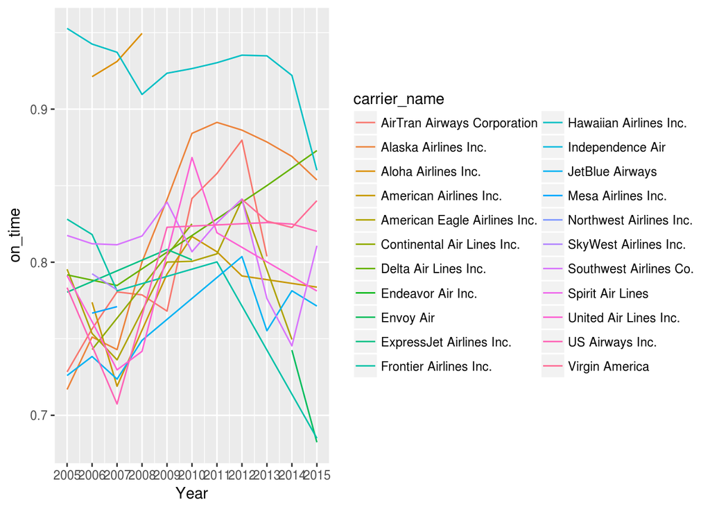

The above line plot looks very busy and hard to follow for the audience. Because of that, I chose to focus on primarily two sets of top five airlines: + Top 5 airlines that have the average largest number of delayed flights in the past 10 years + Top 5 airlines that have the average largest number of on-time flights in the past 10 years

Beyond that, I want to also focus on evaluating the performance of the top five airlines with the largest number of delayed flights in the past 10 years (2005-2015). To start this process, I have to make a new summary table which includes the average number of arrivals, cancelled flights, diverted flights, delayed flights for each carrier in the last 10 years.

### **Bar plots for top airlines**

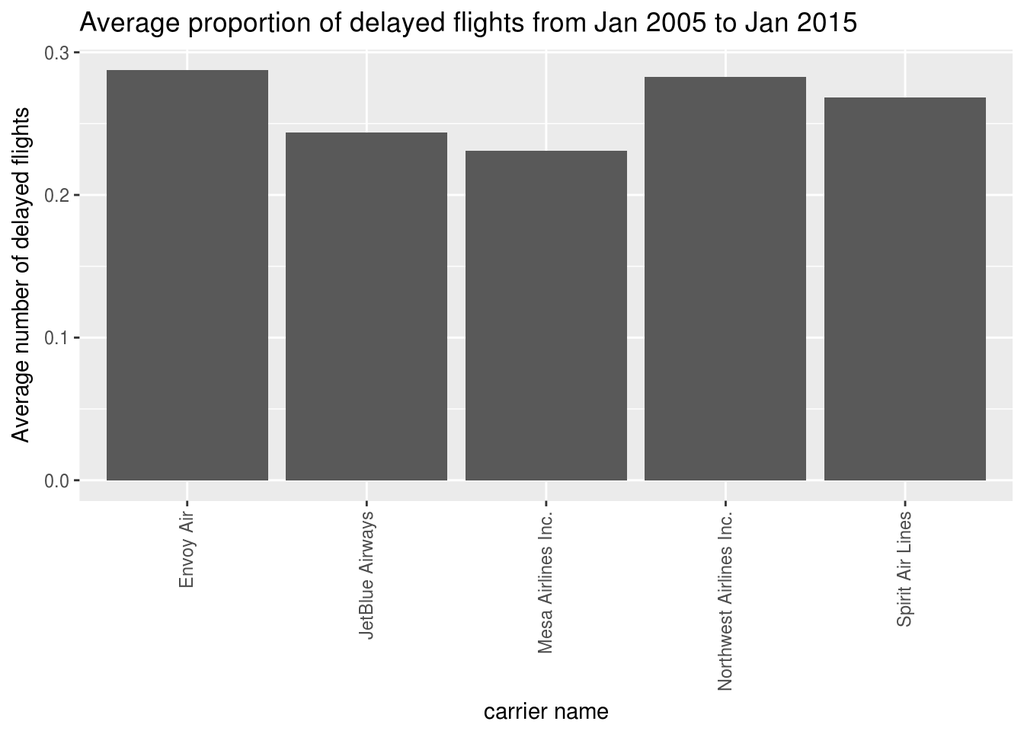

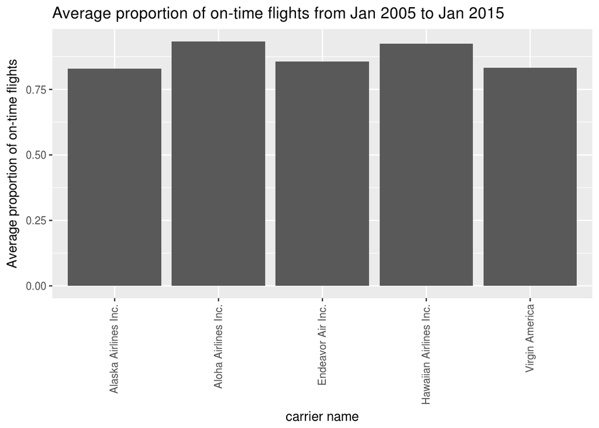

### **Finding the most common delay cause**

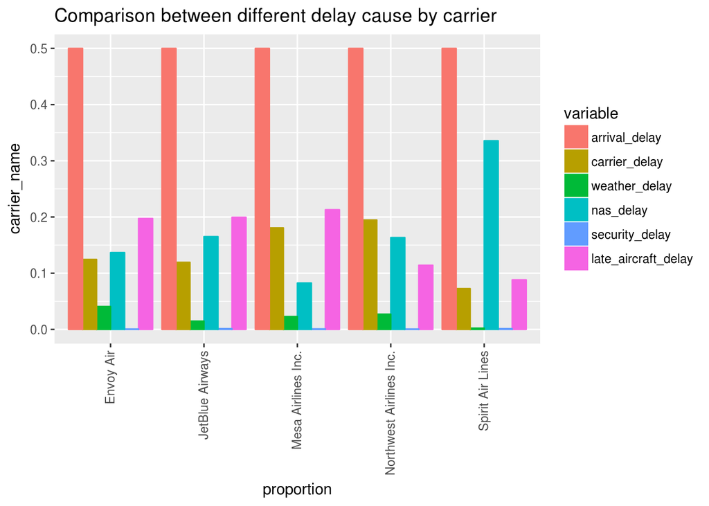

### **Evaluating the performance of all arlines in the top_five_delay list**

To further evaluate the performance of all airlines in the top_five_delayed list, I have subset all their info from the flight_summary dataset before generating any plots for the analysis.

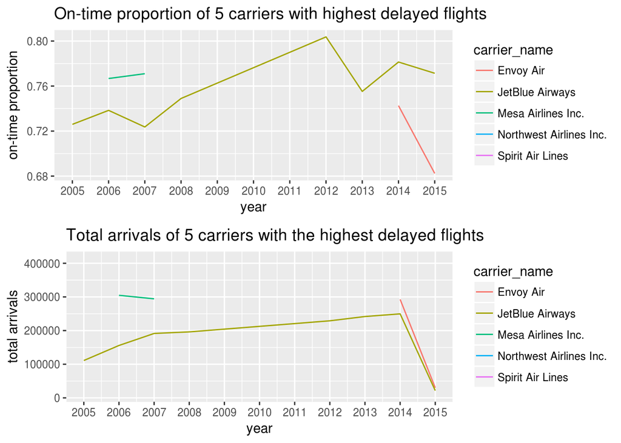

## **CONCLUSION**

Since there is not enough data collected to compare the performance of all airlines within the top_five_Delayed list, no conclusion was made for this section.